# Welcome to Project Based Learning!

Chad Worley

# Mr. Worley

- chad.worley@bartcharter.org
- Canvas: https://bart.instructure.com/courses/1715

# Overview of course

- Projects: Algorithmic Art and Rule-Based Patterns
  - [Frieze](https://en.wikipedia.org/wiki/Frieze_group) patterns
  - [Wallpaper](https://en.wikipedia.org/wiki/Wallpaper_group) patterns
  - [Turtle graphics](https://en.wikipedia.org/wiki/Turtle_graphics) in [Scratch](https://scratch.mit.edu/)
  - [Spirolaterals](https://en.wikipedia.org/wiki/Spirolateral)
  - [Lindenmayer Systems](https://en.wikipedia.org/wiki/L-system)
  - And I am open to suggestions for other algorithmic/rule-based art projects.
    - See [Sol Lewitt](https://massmoca.org/sol-lewitt/)

# Frieze patterns

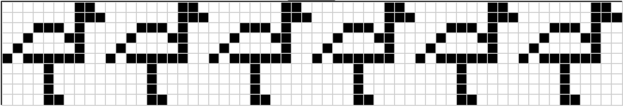

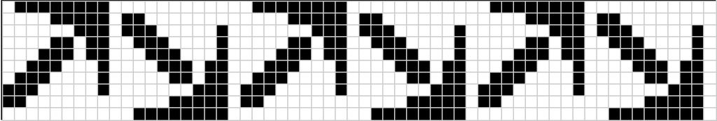

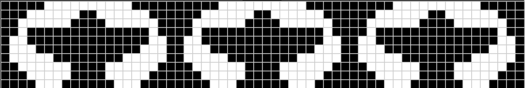

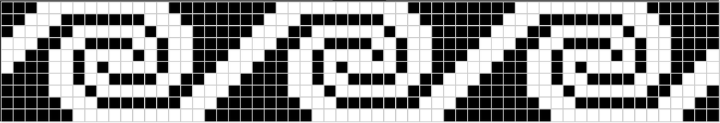

[figure not shown]

[figure not shown]

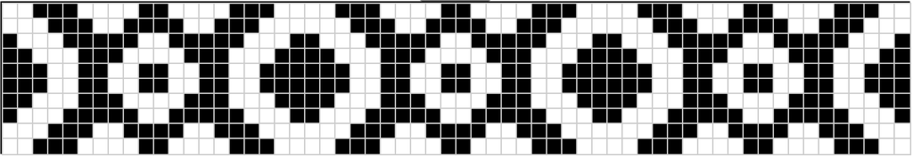

# Wallpaper patterns

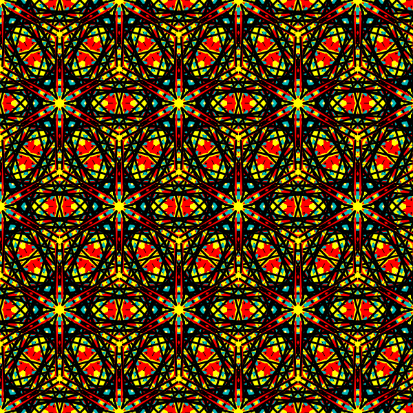

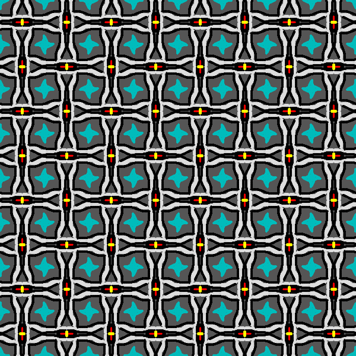

# Spirolaterals

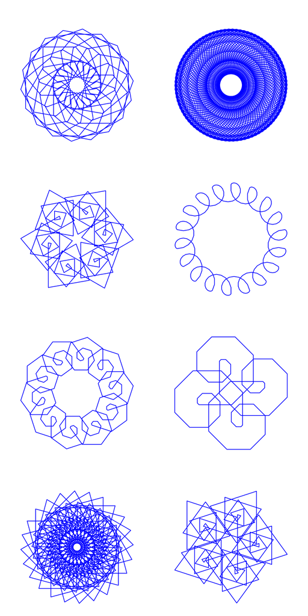

# Lindenmayer systems

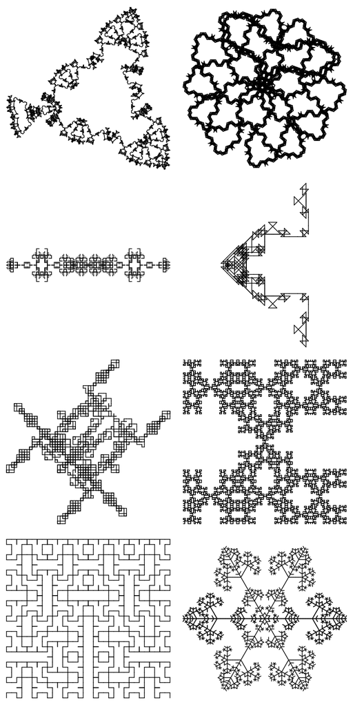

# Handbook

- https://www.bartcharter.org/apps/pages/Student-Handbook
- Phones off and away.
  - NOT simply silent and in pocket!
- No food or drink (except water).
- Do not leave classroom without SmartPass active.
  - Do not leave while you are still in queue.
- Sit in your assigned seat.

# Statements of harm/abuse

- Any statement of intent to do harm (to self or others) will be immediately brought to a professional’s attention.
- Any statement of abuse will be immediately brought to a professional’s attention.

# Frieze-group Transformations

- Four transformations for frieze patterns and wallpaper patterns:
  - Translation, Rotation, Mirror, and Glide!
- **Translation** means copy and shift right:

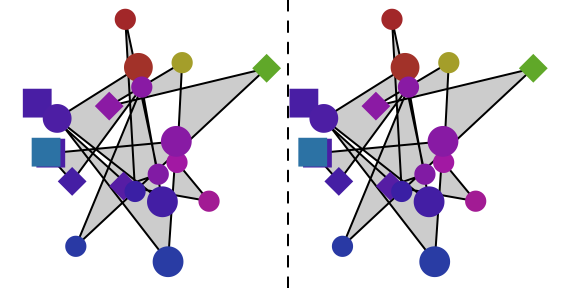

- For frieze patterns, **rotation** means rotation by 180°

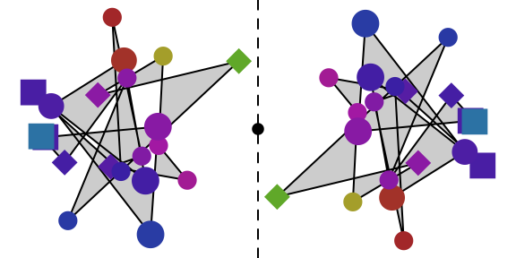

- For frieze patterns, **mirror** means reflection over vertical line

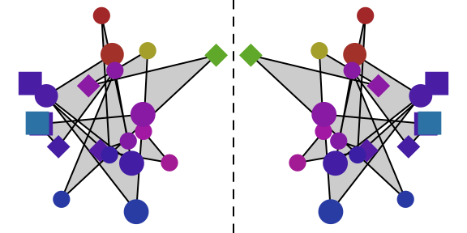

- For frieze patterns, **glide** means reflection over horizontal line, and then shift right

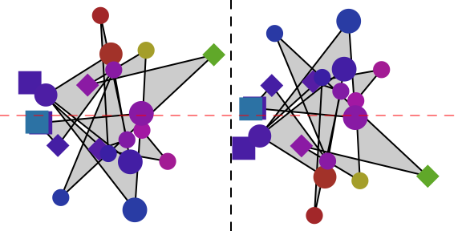

# Transformations!

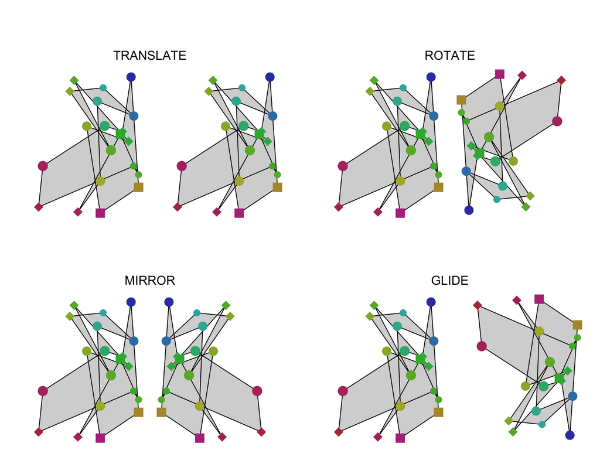